# Hotel_Data

```python
## Load Packages
```

```python
import os
import pandas as pd
import numpy as np
import seaborn as sns
from matplotlib import pyplot as plt
```

Understanding Aspects of Data

adr : average daily rate

adults : number of adults

agent : ID of the travel agency that made the booking

arrival_date_day_of_month : Day of the month of the arrival date

arrival_date_month : Month of arrival date with 12 categories: “January” to “December”

arrival_date_week_number : Week number of the arrival date

arrival_date_year : Year of arrival date

assigned_room_type : Code for the type of room assigned to the booking. Sometimes the assigned room type differs from the reserved room type due to hotel operation reasons (e.g. overbooking) or by customer request. Code is presented instead of designation for anonymity reasons.

babies : Number of babies

booking_changes : Number of changes/amendments made to the booking from the moment the booking was entered on the PMS until the moment of check-in or cancellation.

children : Number of children.

company : ID of the company/entity that made the booking or responsible for paying the booking. ID is presented instead of designation for anonymity reasons.

country : Country of origin. Categories are represented in the ISO 3155–3:2013 format

customer_type : Type of booking, assuming one of four categories :

Contract - when the booking has an allotment or other type of contract associated to it;

Group – when the booking is associated to a group;

Transient – when the booking is not part of a group or contract, and is not associated to other transient booking;

Transient-party – when the booking is transient, but is associated to at least other transient booking

days_in_waiting_list : Number of days the booking was in the waiting list before it was confirmed to the customer

deposit_type : Indication on if the customer made a deposit to guarantee the booking. This variable can assume three categories:

No Deposit – no deposit was made.

Non Refund – a deposit was made in the value of the total stay cost.

Refundable – a deposit was made with a value under the total cost of stay.

distribution_channel : Booking distribution channel. The term “TA” means “Travel Agents” and “TO” means “Tour Operators”.

is_canceled : Value indicating if the booking was canceled (1) or not (0).

is_repeated_quests : Value indicating if the booking name was from a repeated guest (1) or not (0).

lead_time : Number of days that elapsed between the entering date of the booking into the PMS and the arrival date.

market_segment : Market segment designation. In categories, the term “TA” means “Travel Agents” and “TO” means “Tour Operators”.

meal : Type of meal booked. Categories are presented in standard hospitality meal packages:

Undefined/SC – no meal package BB – Bed & Breakfast HB – Half board (breakfast and one other meal – usually dinner) FB – Full board (breakfast, lunch and dinner)

previous_bookings_not_canceled : Number of previous bookings not cancelled by the customer prior to the current booking.

previous_cancellations : Number of previous bookings that were cancelled by the customer prior to the current booking.

required_car_parking_spaces : Number of car parking spaces required by the customer.

reservation_status : Reservation last status, assuming one of three categories:

Canceled – booking was canceled by the customer Check-Out – customer has checked in but already departed No-Show – customer did not check-in and did inform the hotel of the reason why

reservation_status_date : Date at which the last status was set. This variable can be used in conjunction with the ReservationStatus to understand when was the booking canceled or when did the customer checked-out of the hotel.

reserved_room_type : Code of room type reserved. Code is presented instead of designation for anonymity reasons.

stays_in_weekend_nights : Number of weekend nights (Saturday or Sunday) the guest stayed or booked to stay at the hotel.

stays_in_week_nights : Number of week nights (Monday to Friday) the guest stayed or booked to stay at the hotel.

total_of_special_requests : Number of special requests made by the customer (e.g. twin bed or high floor).

# Read and Understand the Data

```python
hotel_data = pd.read_csv('/Users/doyin/documents/Data Projects/hotel_bookings.csv')
hotel_data.head(5)  # check first 5 rows of data
```

|  | hotel | is_canceled | lead_time | arrival_date_year | arrival_date_month | arrival_date_week_number | arrival_date_day_of_month | stays_in_weekend_nights | stays_in_week_nights | adults | ... | deposit_type | agent | company | days_in_waiting_list | customer_type | adr | required_car_parking_spaces | total_of_special_requests | reservation_status | reservation_status_date |
| --- | --- | --- | --- | --- | --- | --- | --- | --- | --- | --- | --- | --- | --- | --- | --- | --- | --- | --- | --- | --- | --- |
| 0 | Resort Hotel | 0 | 342 | 2015 | July | 27 | 1 | 0 | 0 | 2 | ... | No Deposit | NaN | NaN | 0 | Transient | 0.0 | 0 | 0 | Check-Out | 2015-07-01 |
| 1 | Resort Hotel | 0 | 737 | 2015 | July | 27 | 1 | 0 | 0 | 2 | ... | No Deposit | NaN | NaN | 0 | Transient | 0.0 | 0 | 0 | Check-Out | 2015-07-01 |
| 2 | Resort Hotel | 0 | 7 | 2015 | July | 27 | 1 | 0 | 1 | 1 | ... | No Deposit | NaN | NaN | 0 | Transient | 75.0 | 0 | 0 | Check-Out | 2015-07-02 |
| 3 | Resort Hotel | 0 | 13 | 2015 | July | 27 | 1 | 0 | 1 | 1 | ... | No Deposit | 304.0 | NaN | 0 | Transient | 75.0 | 0 | 0 | Check-Out | 2015-07-02 |
| 4 | Resort Hotel | 0 | 14 | 2015 | July | 27 | 1 | 0 | 2 | 2 | ... | No Deposit | 240.0 | NaN | 0 | Transient | 98.0 | 0 | 1 | Check-Out | 2015-07-03 |

5 rows × 32 columns

```python
hotel_data.dtypes # understanding the format of the data
```

```
hotel                              object
is_canceled                         int64
lead_time                           int64
arrival_date_year                   int64
arrival_date_month                 object
arrival_date_week_number            int64
arrival_date_day_of_month           int64
stays_in_weekend_nights             int64
stays_in_week_nights                int64
adults                              int64
children                          float64
babies                              int64
meal                               object
country                            object
market_segment                     object
distribution_channel               object
is_repeated_guest                   int64
previous_cancellations              int64
previous_bookings_not_canceled      int64
reserved_room_type                 object
assigned_room_type                 object
booking_changes                     int64
deposit_type                       object
agent                             float64
company                           float64
days_in_waiting_list                int64
customer_type                      object
adr                               float64
required_car_parking_spaces         int64
total_of_special_requests           int64
reservation_status                 object
reservation_status_date            object
dtype: object
```

# Deciding on Variables

```python
# deleting agent and company column

del hotel_data["agent"]
del hotel_data["company"]
```

```python
# looking further into unsure columns to decide if data is useful
hotel_data["market_segment"].describe()
```

```
count        119390
unique            8
top       Online TA
freq          56477
Name: market_segment, dtype: object
```

```python
hotel_data["market_segment"].unique()
```

```
array(['Direct', 'Corporate', 'Online TA', 'Offline TA/TO',
       'Complementary', 'Groups', 'Undefined', 'Aviation'], dtype=object)
```

```python
del hotel_data["market_segment"]
```

```python
del hotel_data["distribution_channel"]
```

Checking for columns where the sum of null values is more than 70% of total rows

```python
for col in hotel_data.columns:
    if np.sum (hotel_data[col].isnull()) > (hotel_data.shape[0]*0.70):
        print(col)
```

```
company
```

```python
# cancelled column variable can be changed

hotel_data["is_canceled"].dtype
```

```
dtype('int64')
```

```python
new_is_canceled = pd.Categorical(hotel_data["is_canceled"])
new_is_canceled = new_is_canceled.rename_categories(["Cancelled","Booked"])

new_is_canceled.describe()
```

| categories | counts | freqs |
| --- | --- | --- |
| Cancelled | 75011 | 0.629234 |
| Booked | 44199 | 0.370766 |

```python
hotel_data["Booking Status"] = new_is_canceled
```

```python
hotel_data.head(5)
```

|  | hotel | is_canceled | lead_time | arrival_date_year | arrival_date_month | arrival_date_week_number | arrival_date_day_of_month | stays_in_weekend_nights | stays_in_week_nights | adults | ... | agent | company | days_in_waiting_list | customer_type | adr | required_car_parking_spaces | total_of_special_requests | reservation_status | reservation_status_date | Booking Status |
| --- | --- | --- | --- | --- | --- | --- | --- | --- | --- | --- | --- | --- | --- | --- | --- | --- | --- | --- | --- | --- | --- |
| 0 | Resort Hotel | 0 | 342 | 2015 | July | 27 | 1 | 0 | 0 | 2 | ... | NaN | NaN | 0 | Transient | 0.0 | 0 | 0 | Check-Out | 2015-07-01 | Cancelled |
| 1 | Resort Hotel | 0 | 737 | 2015 | July | 27 | 1 | 0 | 0 | 2 | ... | NaN | NaN | 0 | Transient | 0.0 | 0 | 0 | Check-Out | 2015-07-01 | Cancelled |
| 2 | Resort Hotel | 0 | 7 | 2015 | July | 27 | 1 | 0 | 1 | 1 | ... | NaN | NaN | 0 | Transient | 75.0 | 0 | 0 | Check-Out | 2015-07-02 | Cancelled |
| 3 | Resort Hotel | 0 | 13 | 2015 | July | 27 | 1 | 0 | 1 | 1 | ... | 304.0 | NaN | 0 | Transient | 75.0 | 0 | 0 | Check-Out | 2015-07-02 | Cancelled |
| 4 | Resort Hotel | 0 | 14 | 2015 | July | 27 | 1 | 0 | 2 | 2 | ... | 240.0 | NaN | 0 | Transient | 98.0 | 0 | 1 | Check-Out | 2015-07-03 | Cancelled |

5 rows × 33 columns

```python
# del hotel_data[is_canceled]
```

# Combining Dates Columns

hotel_data["Arrival Date"] = pd.to_datetime(hotel_data["arrival_date_year"].astype(str) + '/' + hotel_data["arrival_date_month"].astype(str) + '/' + hotel_data["arrival_date_day_of_month"].astype(str))

```python
hotel_data["Arrival Date"] = pd.to_datetime(hotel_data["arrival_date_year"].astype(str) + '/' + hotel_data["arrival_date_month"].astype(str) + '/' + hotel_data["arrival_date_day_of_month"].astype(str))
```

```python
hotel_data.head(5)
```

|  | hotel | is_canceled | lead_time | arrival_date_year | arrival_date_month | arrival_date_week_number | arrival_date_day_of_month | stays_in_weekend_nights | stays_in_week_nights | adults | ... | company | days_in_waiting_list | customer_type | adr | required_car_parking_spaces | total_of_special_requests | reservation_status | reservation_status_date | Booking Status | Arrival Date |
| --- | --- | --- | --- | --- | --- | --- | --- | --- | --- | --- | --- | --- | --- | --- | --- | --- | --- | --- | --- | --- | --- |
| 0 | Resort Hotel | 0 | 342 | 2015 | July | 27 | 1 | 0 | 0 | 2 | ... | NaN | 0 | Transient | 0.0 | 0 | 0 | Check-Out | 2015-07-01 | Cancelled | 2015-07-01 |
| 1 | Resort Hotel | 0 | 737 | 2015 | July | 27 | 1 | 0 | 0 | 2 | ... | NaN | 0 | Transient | 0.0 | 0 | 0 | Check-Out | 2015-07-01 | Cancelled | 2015-07-01 |
| 2 | Resort Hotel | 0 | 7 | 2015 | July | 27 | 1 | 0 | 1 | 1 | ... | NaN | 0 | Transient | 75.0 | 0 | 0 | Check-Out | 2015-07-02 | Cancelled | 2015-07-01 |
| 3 | Resort Hotel | 0 | 13 | 2015 | July | 27 | 1 | 0 | 1 | 1 | ... | NaN | 0 | Transient | 75.0 | 0 | 0 | Check-Out | 2015-07-02 | Cancelled | 2015-07-01 |
| 4 | Resort Hotel | 0 | 14 | 2015 | July | 27 | 1 | 0 | 2 | 2 | ... | NaN | 0 | Transient | 98.0 | 0 | 1 | Check-Out | 2015-07-03 | Cancelled | 2015-07-01 |

5 rows × 34 columns

```python
# combining children and babies

hotel_data["children"].describe()
```

```
count    119210.000000
mean          0.104047
std           0.398835
min           0.000000
25%           0.000000
50%           0.000000
75%           0.000000
max          10.000000
Name: children, dtype: float64
```

```python
np.sum(hotel_data.isnull())
```

```
hotel                                  0
is_canceled                            0
lead_time                              0
arrival_date_year                      0
arrival_date_month                     0
arrival_date_week_number               0
arrival_date_day_of_month              0
stays_in_weekend_nights                0
stays_in_week_nights                   0
adults                                 0
children                               0
babies                                 0
meal                                   0
country                              478
market_segment                         0
distribution_channel                   0
is_repeated_guest                      0
previous_cancellations                 0
previous_bookings_not_canceled         0
reserved_room_type                     0
assigned_room_type                     0
booking_changes                        0
deposit_type                           0
agent                              16280
company                           112442
days_in_waiting_list                   0
customer_type                          0
adr                                    0
required_car_parking_spaces            0
total_of_special_requests              0
reservation_status                     0
reservation_status_date                0
Booking Status                         0
Arrival Date                           0
dtype: int64
```

```python
new_children = np.where(hotel_data["children"].isnull(),
                       np.mean(hotel_data["children"]),
                       hotel_data["children"])

hotel_data["children"] = new_children

np.sum(hotel_data["children"].isnull())
```

```
0
```

```python
hotel_data["Children"]=hotel_data["children"].astype(int) + hotel_data["babies"].astype(int)
```

```python
hotel_data.isnull().sum()
```

```
hotel                                  0
is_canceled                            0
lead_time                              0
arrival_date_year                      0
arrival_date_month                     0
arrival_date_week_number               0
arrival_date_day_of_month              0
stays_in_weekend_nights                0
stays_in_week_nights                   0
adults                                 0
children                               0
babies                                 0
meal                                   0
country                              478
market_segment                         0
distribution_channel                   0
is_repeated_guest                      0
previous_cancellations                 0
previous_bookings_not_canceled         0
reserved_room_type                     0
assigned_room_type                     0
booking_changes                        0
deposit_type                           0
agent                              16280
company                           112442
days_in_waiting_list                   0
customer_type                          0
adr                                    0
required_car_parking_spaces            0
total_of_special_requests              0
reservation_status                     0
reservation_status_date                0
Booking Status                         0
Arrival Date                           0
Children                               0
dtype: int64
```

```python
# hotel cancelled bookings
hotel_data['Booking Status'].value_counts()
```

```
Cancelled    75011
Booked       44199
Name: Booking Status, dtype: int64
```

```python
Cancelled = hotel_data[hotel_data["Booking Status"] == "Cancelled"]
Cancelled_per = (len(Cancelled)/hotel_data["Booking Status"].shape[0])*100
#here I have shown how to use shape[0] to get the total number of rows also use len() to get the total number of rows cancelled

Cancelled_per
```

```
62.9234124653972
```

```python
hotel_data["arrival_date_month"].value_counts()
```

```
August       13861
July         12644
May          11780
October      11147
April        11078
June         10929
September    10500
March         9768
February      8052
November      6771
December      6759
January       5921
Name: arrival_date_month, dtype: int64
```

# Errors

The columns for adults & children cannot be blank for the same row as this will mean no one is in the room. We can also assume that a booking cannot have children with having adults.

```python
filter = (hotel_data.children == 0) & (hotel_data.adults == 0)
hotel_data[filter]
```

[output not shown]

180 rows × 32 columns

Data indicates there are 180 rows where children and adults are blank

```python
## drop rows that have 0 for children and adults

error_guest = hotel_data[(hotel_data.children == 0) & (hotel_data.adults == 0)].index

hotel_data.drop(error_guest, inplace = True)

## reset index to new dataset
hotel_data.reset_index(drop = True, inplace=True)
hotel_data.head()
```

|  | hotel | is_canceled | lead_time | arrival_date_year | arrival_date_month | arrival_date_week_number | arrival_date_day_of_month | stays_in_weekend_nights | stays_in_week_nights | adults | ... | deposit_type | agent | company | days_in_waiting_list | customer_type | adr | required_car_parking_spaces | total_of_special_requests | reservation_status | reservation_status_date |
| --- | --- | --- | --- | --- | --- | --- | --- | --- | --- | --- | --- | --- | --- | --- | --- | --- | --- | --- | --- | --- | --- |
| 0 | Resort Hotel | 0 | 342 | 2015 | July | 27 | 1 | 0 | 0 | 2 | ... | No Deposit | NaN | NaN | 0 | Transient | 0.0 | 0 | 0 | Check-Out | 2015-07-01 |
| 1 | Resort Hotel | 0 | 737 | 2015 | July | 27 | 1 | 0 | 0 | 2 | ... | No Deposit | NaN | NaN | 0 | Transient | 0.0 | 0 | 0 | Check-Out | 2015-07-01 |
| 2 | Resort Hotel | 0 | 7 | 2015 | July | 27 | 1 | 0 | 1 | 1 | ... | No Deposit | NaN | NaN | 0 | Transient | 75.0 | 0 | 0 | Check-Out | 2015-07-02 |
| 3 | Resort Hotel | 0 | 13 | 2015 | July | 27 | 1 | 0 | 1 | 1 | ... | No Deposit | 304.0 | NaN | 0 | Transient | 75.0 | 0 | 0 | Check-Out | 2015-07-02 |
| 4 | Resort Hotel | 0 | 14 | 2015 | July | 27 | 1 | 0 | 2 | 2 | ... | No Deposit | 240.0 | NaN | 0 | Transient | 98.0 | 0 | 1 | Check-Out | 2015-07-03 |

5 rows × 32 columns

Checking rows were dropped - 119390 minus 180 = 119210

```python
hotel_data.info()
```

```
<class 'pandas.core.frame.DataFrame'>
RangeIndex: 119210 entries, 0 to 119209
Data columns (total 32 columns):
 #   Column                          Non-Null Count   Dtype
---  ------                          --------------   -----
 0   hotel                           119210 non-null  object
 1   is_canceled                     119210 non-null  int64
 2   lead_time                       119210 non-null  int64
 3   arrival_date_year               119210 non-null  int64
 4   arrival_date_month              119210 non-null  object
 5   arrival_date_week_number        119210 non-null  int64
 6   arrival_date_day_of_month       119210 non-null  int64
 7   stays_in_weekend_nights         119210 non-null  int64
 8   stays_in_week_nights            119210 non-null  int64
 9   adults                          119210 non-null  int64
```

[output cut: 24 more lines]

# Visualising the data

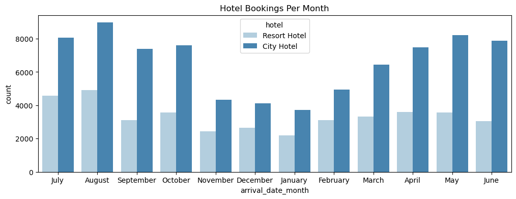

```python
plt.figure(figsize = (12,4))
sns.countplot(x = 'arrival_date_month', hue = 'hotel',data = hotel_data, palette = 'Blues')

plt.title("Hotel Bookings Per Month")
```

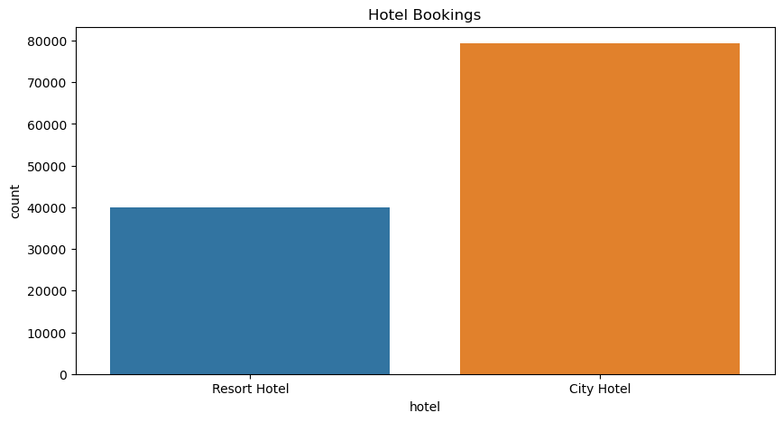

```python
plt.figure(figsize = (10,5))
sns.countplot(x = 'hotel', data = hotel_data)

plt.title("Hotel Bookings")
```

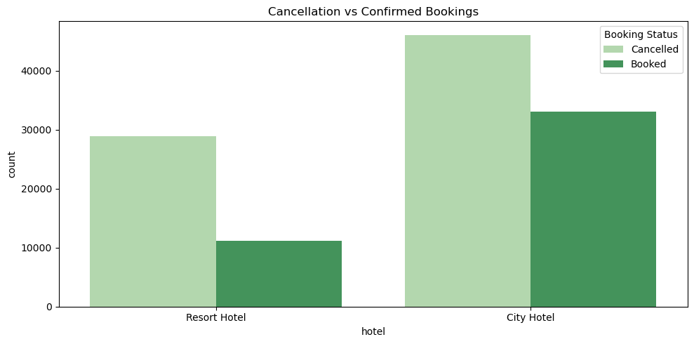

```python
plt.figure(figsize = (10,5))

sns.countplot(x = 'hotel', data = hotel_data, hue = 'Booking Status', palette = 'Greens')
plt.title("Cancellation vs Confirmed Bookings")

plt.tight_layout()
```

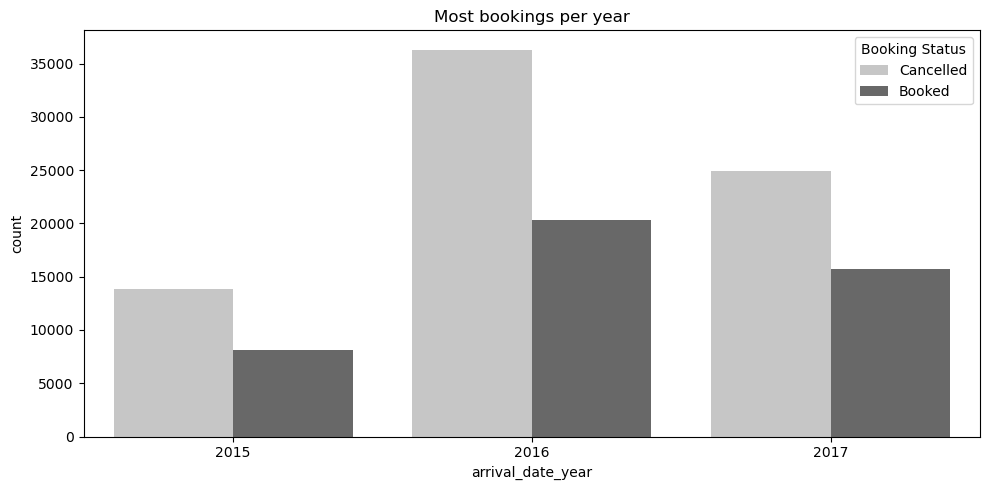

```python
plt.figure(figsize = (10,5))

sns.countplot(x = 'arrival_date_year', data = hotel_data, hue = 'Booking Status', palette = 'Greys')
plt.title("Most bookings per year")

plt.tight_layout()
```

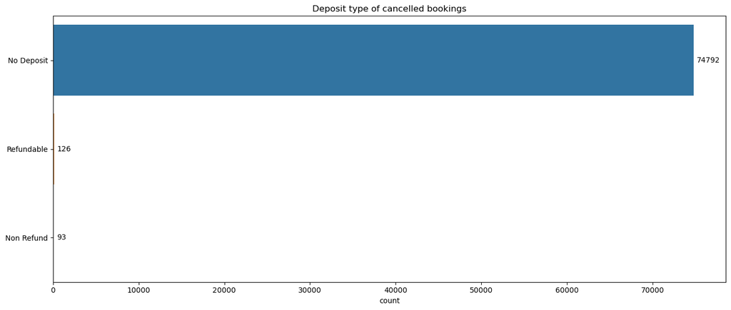

```python
fig, ax = plt.subplots(figsize = (14, 6))

sns.countplot(ax = ax,
            y = 'deposit_type',
            data = Cancelled,
            orient = "h",
            ).set(ylabel = None)
ax.bar_label(ax.containers[0], padding = 4)
plt.title('Deposit type of cancelled bookings')

plt.tight_layout()
```

```python
non_can = (hotel_data["Booking Status"]== "Booked")
hotel_data[non_can]
```

|  | hotel | is_canceled | lead_time | arrival_date_year | arrival_date_month | arrival_date_week_number | arrival_date_day_of_month | stays_in_weekend_nights | stays_in_week_nights | adults | ... | days_in_waiting_list | customer_type | adr | required_car_parking_spaces | total_of_special_requests | reservation_status | reservation_status_date | Booking Status | Arrival Date | Children |
| --- | --- | --- | --- | --- | --- | --- | --- | --- | --- | --- | --- | --- | --- | --- | --- | --- | --- | --- | --- | --- | --- |
| 8 | Resort Hotel | 1 | 85 | 2015 | July | 27 | 1 | 0 | 3 | 2 | ... | 0 | Transient | 82.0 | 0 | 1 | Canceled | 2015-05-06 | Booked | 2015-07-01 | 0 |
| 9 | Resort Hotel | 1 | 75 | 2015 | July | 27 | 1 | 0 | 3 | 2 | ... | 0 | Transient | 105.5 | 0 | 0 | Canceled | 2015-04-22 | Booked | 2015-07-01 | 0 |
| 10 | Resort Hotel | 1 | 23 | 2015 | July | 27 | 1 | 0 | 4 | 2 | ... | 0 | Transient | 123.0 | 0 | 0 | Canceled | 2015-06-23 | Booked | 2015-07-01 | 0 |
| 27 | Resort Hotel | 1 | 60 | 2015 | July | 27 | 1 | 2 | 5 | 2 | ... | 0 | Transient | 107.0 | 0 | 2 | Canceled | 2015-05-11 | Booked | 2015-07-01 | 0 |
| 32 | Resort Hotel | 1 | 96 | 2015 | July | 27 | 1 | 2 | 8 | 2 | ... | 0 | Transient | 108.3 | 0 | 2 | Canceled | 2015-05-29 | Booked | 2015-07-01 | 0 |
| ... | ... | ... | ... | ... | ... | ... | ... | ... | ... | ... | ... | ... | ... | ... | ... | ... | ... | ... | ... | ... | ... |
| 108671 | City Hotel | 1 | 25 | 2017 | May | 18 | 6 | 2 | 1 | 1 | ... | 0 | Transient | 125.0 | 0 | 0 | No-Show | 2017-05-06 | Booked | 2017-05-06 | 0 |
| 111191 | City Hotel | 1 | 4 | 2017 | June | 23 | 5 | 1 | 0 | 1 | ... | 0 | Transient | 65.0 | 0 | 0 | Canceled | 2017-06-05 | Booked | 2017-06-05 | 0 |
| 111756 | City Hotel | 1 | 7 | 2017 | May | 22 | 31 | 0 | 1 | 1 | ... | 0 | Transient | 65.0 | 0 | 0 | Canceled | 2017-05-31 | Booked | 2017-05-31 | 0 |
| 111757 | City Hotel | 1 | 6 | 2017 | July | 29 | 17 | 1 | 0 | 1 | ... | 0 | Transient | 65.0 | 0 | 0 | No-Show | 2017-07-17 | Booked | 2017-07-17 | 0 |
| 117115 | City Hotel | 1 | 0 | 2017 | August | 31 | 2 | 0 | 2 | 1 | ... | 0 | Transient | 65.0 | 0 | 1 | No-Show | 2017-08-02 | Booked | 2017-08-02 | 0 |

44199 rows × 35 columns

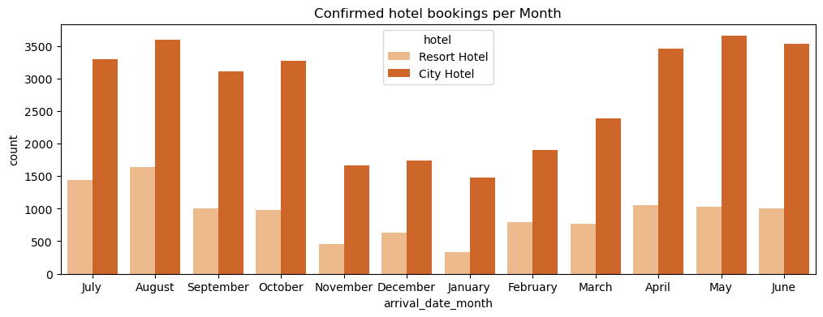

```python
plt.figure(figsize = (12,4))
sns.countplot(x = 'arrival_date_month', hue = 'hotel',data = hotel_data[non_can], palette = 'Oranges')

plt.title("Confirmed hotel bookings per Month")
```

Room Type A is the most popular room with 85,873 reserved across the years.

```python
hotel_data["reserved_room_type"].value_counts()
```

```
A    85873
D    19179
E     6519
F     2894
G     2092
B     1115
C      931
H      601
L        6
Name: reserved_room_type, dtype: int64
```

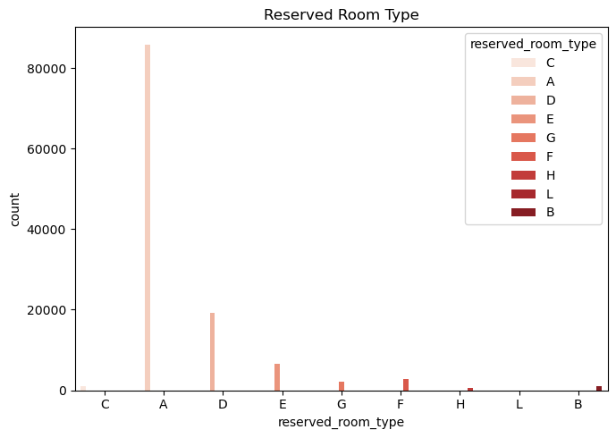

```python
plt.figure(figsize = (7,5))

sns.countplot(x = 'reserved_room_type', data = hotel_data, hue = 'reserved_room_type', palette = 'Reds')
plt.title("Reserved Room Type")

plt.tight_layout()
```

```python
filter_room = (hotel_data["reserved_room_type"] == hotel_data["assigned_room_type"])
(filter_room.value_counts()/hotel_data.shape[0])*100
```

```
True     87.58829
False    12.41171
dtype: float64
```

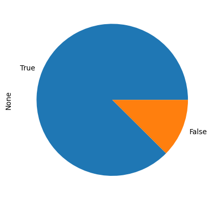

```python
filter_room.value_counts().plot(kind='pie')
```

Using a boolean data type to see if the room customers reserved was the same as what they were assigned. 88% of guests were assigned the room they reserved.